# Building Management Reports using flexdashboard

25 February 2020  
Slides: https://alice-hannah.github.io/presentations-and-blogs/2020-02-25_flexdashboard/slides.html

## Background and Motivation

- Quarterly management reports for [Dementia Post Diagnostic Support (PDS)](https://www.isdscotland.org/Health-Topics/Mental-Health/Dementia-Post-diagnostic-Support/) data
- SPSS used for data preparation and calculating performance measures
- Excel used to present data
- New data recording guidance prompted review of methodology and presentation of management reports

## Why flexdashboard?

- Process can be automated using R and R Markdown
- Output can include interactive elements
- Output as a stand alone html file
  - Universal file format
  - No requirement for password protected shiny server
  - Can continue to be distributed via email to restrict access
- Looks swish!

## Using flexdashboard

Define output as flexdashboard in YAML header of R Markdown document:

```r
---
title: "Dementia PDS Quarterly Management Report"
output:
  flexdashboard::flex_dashboard:
    navbar:
      - title: "Data as at 31 December 2019"
    logo: isdscotland.png
    orientation: rows
    vertical_layout: scroll
---
```

## Using flexdashboard

Add a new row…

```r
Row
-------------------------------------------------
```

Add multiple pages…

```r
Home
=================================================
```

Create a tabset to switch between sections…

```r
Row {.tabset}
-------------------------------------------------
```

## Using flexdashboard

```r
flexdashboard::valueBox(paste0(80, "%"),
                        icon = "fa-percent",
                        caption = paste("of people estimated to be newly",
                                        " diagnosed with dementia were referred",
                                        " for post-diagnostic support.")
)
```

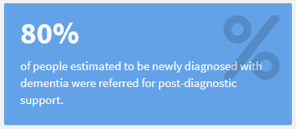

## R Markdown Child Templates

- Used to create multiple pages with the same layout for each financial year and health board, thus avoiding duplication of code
- Write separate R Markdown document called a “child” template
- Use `knitr::knit_child()` in the main markdown document to knit the “child” template for each combination of parameters
- [Tutorial to use R Markdown Childs with flexdashboard](https://somtom.github.io/post/using-dynamically-rendered-r-markdown-childs-for-reports/)

## Next Steps

- Automate date in navbar so dashboard is fully automated
- Improve comments/documentation of code
- Develop further data analysis
- Develop as shiny dashboard when infrastructure available

## Contact & Links

### Alice Byers - Health & Social Care Team

- Email - alice.byers@nhs.net
- GitHub - alice-hannah

### Useful Links

- [flexdashboard](https://rmarkdown.rstudio.com/flexdashboard/index.html)
- [Tutorial to use R Markdown Childs with flexdashboard](https://somtom.github.io/post/using-dynamically-rendered-r-markdown-childs-for-reports/)